# Task 1: Spatial Data Viz

Vanessa Rathbone

2/19/2021

## California DFW Oil Spill Incident Tracking Interactive Map and Chloropleth Maps

**Summary:** The database system is designed to provide OSPR with quantified statistical data on oil spill response by OSPR field responders. The OSPR Incident Tracking Database System project was initiated to provide OSPR with oil spill incident data for statistical evaluation and justification for program planning, drills and exercise training and development, legislative analysis, budget preparation, to inform and educate the public and analyze OSPR’s overall spill preparedness and response performance. An “incident”, for purposes of this database, is “a discharge or threatened discharge of petroleum or other deleterious material into the waters of the state.”

**Description:** The Office of Spill Prevention and Response (OSPR) Incident Tracking Database is a statewide oil spill tracking information system. The data are collected by OSPR Field Response Team members for Marine oil spills and by OSPR Inland Pollution Coordinators and Wardens for Inland incidents.

**Data source:** California Department of Fish and Game, Office of Spill Prevention and Response (2008). [Oil Spill Incident Tracking, 07/23/2008.](https://map.dfg.ca.gov/metadata/ds0394.html)

### Read in the data and check CRS

```r
#read in the oil spill layer:
ca_oil <- read_sf(here("data","ds394"), layer = "ds394") %>%
  clean_names()

#check the projection
#st_crs(ca_oil) #NAD83 or 3310

#read in the CA county data:
ca_counties <- read_sf(here("data", "ca_counties"), layer = "CA_Counties_TIGER2016") %>%
  clean_names() %>%
  select(name)

#check projection
#st_crs(ca_counties) #WGS 84 - not the same

#make the same projections
ca_counties <- st_transform(ca_counties, st_crs(ca_oil))
#st_crs(ca_counties)

# plot(ca_counties)
# plot(ca_oil)

#make a quick ggplot
# ggplot() +
#   geom_sf(data = ca_counties) +
#   geom_sf(data = ca_oil, aes(color = dfgcontrol))
```

### 1) Interactive map using tmap() showing the oil spills per oil well in California.

```r
#final interactive map showing the location of oil spill events included in the data
tmap_mode("view")

#tm_shape(ca_oil) +
  #tm_dots("dfgcontrol")

#tm_shape(ca_oil) +
  #tm_dots("localecoun")

ca_oil_tmap <- tm_shape(ca_oil) +
  tm_dots("specificlo")

ca_oil_tmap
```

[interactive chart not shown]

```r
#tm_shape(ca_subset) +
  #tm_fill("land_area", palette = "BuGn") +
  #tm_shape(sesbania) +
  #tm_dots() +
  #save_tmap(ca_oil_tmap, filename = "ca_oil_tmap.jpg")
```

*Figure 1. Interactive map of oil spills per well captured by the California Department of Fish and Wildlife Oil Spill Incident Tracking. Specifically, showing the location broken out by fresh water, land or marine locations.*

### 2) Static Chloropleth Map of inland oil spill events by county

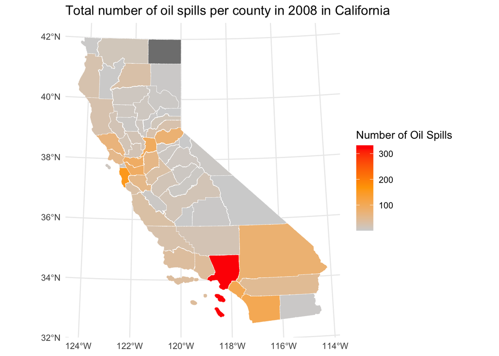

*Figure 2. Chloropleth map of only inland oil spill events by country.*

```r
#wrangle the data to only include count by county of inland oil spill events in 2008
ca_inland <- ca_oil %>%
  select(dfgcontrol, dateofinci, inlandmari, localecoun, latitude, longitude, geometry) %>%
  rename(date = dateofinci) %>%
  filter(inlandmari == "Inland") %>%
  count(localecoun)

#use st_join to join spatial layers
ca_join <- ca_counties %>%
  st_join(ca_inland)

#make a chloropleth using the number of oil spills as the fill color per county:
ggplot(data = ca_join) +
  geom_sf(aes(fill = n), color = "white", size = 0.1) +
  scale_fill_gradientn(colors = c("lightgray","orange","red")) +
  theme_minimal() +
  labs(fill = "Number of Oil Spills",
       title = "Total number of oil spills per county in 2008 in California")
```